# Exploring the relationship between birth names and TV-shows

Christer Hagenes Opdahl and Kim Grønning Eide

December 2020

# About the project

This project are to analyze the names of newborns in Norway and Sweden, compare the names they get against big TV shows and the relation between them. Firstly a comparison against a big international TV show to see if there exists a big enough influence to affect the choice of names given to newborns. Second, a big TV show for both Norway and Sweden, and analyze if there exists a difference between the influence of international pop culture vs the ”local” trends. Our hypothesis is that when TV-series become exceedingly popular, the names within the series will appear in an increased fashion in the population. We will be comparing Norwegian girls against Swedish girls, and the same with the boys.

# Related Work

There are previous projects which have looked into the relationship between TV-series and baby names. For example, there were a group exploring the relationship between French names and Game of Thrones. However, this research has not been available to the public and we therefore know nothing about the outcome of the project.

While searching on the web, there are multiple web sites reciting popular names in a respective population. This information is often displayed as a list of names. This serves as a good way of displaying popular names, but does not have any further use as there is no indication of relation between the names and different TV-shows.

The research found on the web served as a “what not to do” and became an insight on what we wanted the graphs to look like. They needed to be graphs that would show the popularity of each specific name in relation to the popular series, but also in relation to each other so that each name could be weighed up against each other.

This is what lead to the “simplicity is king” strategy. Displaying the yearly count of each name in a graph containing all names within the tv-series. In addition, a static line to display the year when the series dropped. This is a good way to show the statistic, because its easy to read and there is no need for additional information than the title of the graphic to understand the point being made.

There will be an analyzation of three different TV-series in this project. This choice were made, since the names used in this project are specific to Norway and Sweden. This is an opportune moment to see if there is any difference in the influence of international pop culture, and the pop culture within the different regions.

The three different shows are ”Game Of Thrones”(internationally popular), ”Skam”(popular in Norway) and ”Wallander”(popular in Sweden).

Note that the algorithm which were created for this project, are not limited to these three TV-series, but can be used to analyze any tv-series as long as its listed on IMDB.com.

# Initial Questions

Initially, this project was just interested in seeing if the names used as char- acter names in Game of Thrones, were later seen as names for newborns in the Norwegian and Swedish population. To this end, it was also important to know if any of the names were present within the population before the TV- show started. However, when the results came the from anlalyzation of Game of Thrones, there were a realisation that few of the names from the series were actually used in reality. From this, the logical next step were to look at different the TV-shows that were made in Norway and Sweden and do the same analysis for these. This lead to an issue, some of the names were so popular that it became hard to read the graphs. To mitigate this issue, we limited the amount of episodes that each character played in. Since the popularity of the different names are different from show to show, this limitation is also different between the shows. This is further explained later on.

# Data

### Webscraping

The information about actor names, and how many episodes they were involved in, were webscraped of imdb.com. The scraping were done using python, and the libraries requests and bs4.

### Statistics

All data used in this project, are collected from official sources in Norway and Sweden, respectively SSB and SCB(statistik databasen). The data from both sources contains all newborn baby names from 1998 to 2019, in addition to the number of babies given each name. The data were originally organized as excel files. While using python, converting the files to text files were faster and easier to work with. It becomes faster and easier because you can simply read each line in the file, searching for the character names and if found append into a list for further data wrangling.

The main hurdle to get over in this project was to convert the data sets into usable data structures that were fast and easy to access. The efficiency, were ensured by the above mentioned technique, however, a good amount of additional wrangling were needed to make the information plottable. The source code is heavily commented and should provide good insight on what was done.

# Exploratory Analysis

The decision were made to show the data as different graphs, 4 in total for each TV-show. By splitting the boy names and girl names into different graphs, they became more readable and easier to understand. This was better then the initial plots were there were one plot per TV-show, which contained all names which lead to the graphs being really crowded. There were several discussions on how to achieve the best readability of the graphs, and several attempts were made to this end, such as displaying the statistics as tables. The final result, which is more easily readable and contains a good display of changes over time can be seen below.

The graphics were important that were made in such a way that they were easily readable, they had to be understandable for bystanders without any knowledge about the project. There were multiple renditions, but we ultimately decided to show graphs containing multiple names and when the series came out in the same graph.

A limit on the amount of names that were to be displayed on each graph had to be made, to avoid the graphs being over crowded with names. This were done by setting a limit on each show, in such a way that only the most ”important” character names were displayed. This was particularly important for the Norwegian TV-series ”Skam” which featured an enormous amount of character names spanning over many episodes. For Skam, a limitation on 10 episodes were shown to be an efficient metric. Note that different limits were used for different series. In addition when looking at the graphs, some might say that there are names missing, meaning that there are some popular name that is not present in the graph. This is either due to the above mentioned limit, or due to the fact that there are no newborns named that specific name.

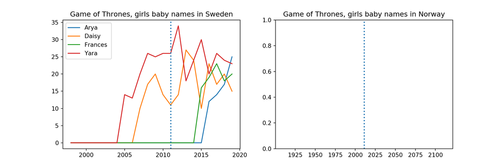

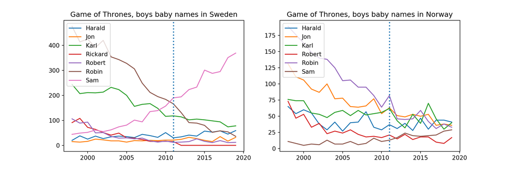

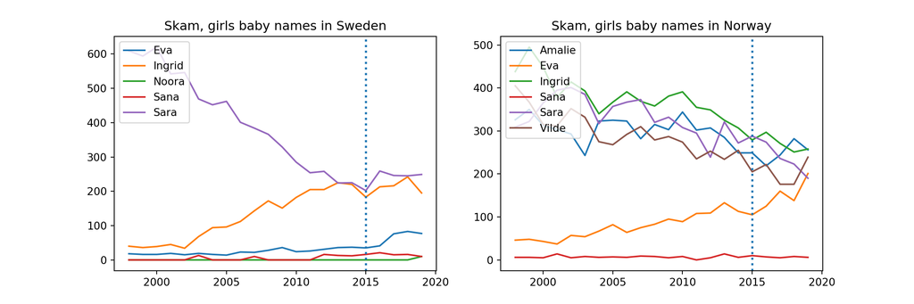

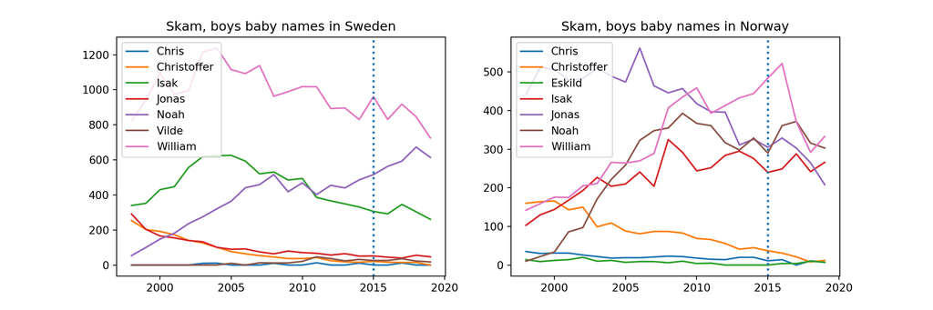

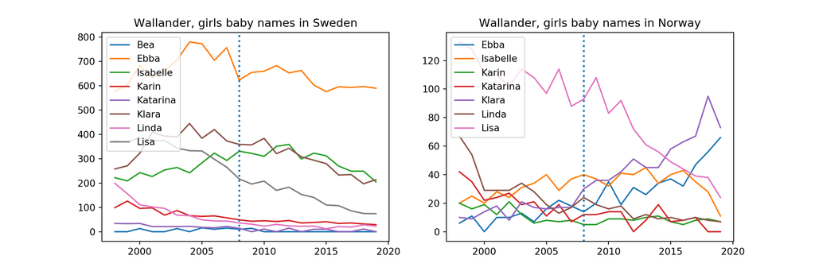

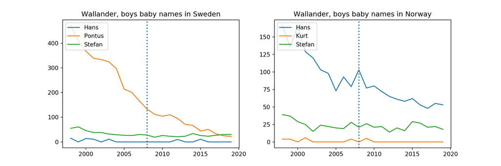

# Final Analysis

The results show that there are some increase in baby names after popular series aired, but very few, and there might need to be an additional discussion if the series itself were the main reason for the increase. Many of the names that became more popular after the series aired, seems to already be increasing in popularity before the different shows came out, which also might be the reason for the names being in the series in the first place. This is very evident in the plots from the Norwegian series “Skam” and the Swedish series “Wallander”. With that said, there is also evidence that points to names being directly linked to the different shows, such as Game Of Thrones. But the statistics is not similar between the two different countries. In Sweden the names grew a lot in popularity in the years following, but in Norway there were no girl names from the show evident in the data. For example Arya, which arguably are the most popular name from Game Of Thrones, are not given to a single newborn baby from 1998 to 2019. However, with further investigation of the data, there were some influx of the “Norwegianized” spelling of the names such as “Aria”. This is however not shown in the plotted statistics, and is not a trivial thing to account for.

Stephen J. Bush, Anna Powell-Smith and Tom C. Freeman suggest in their study ”Network analysis of the social and demographic influences on name choice within the UK(1838-2016)”, that in general people name their children names based on the ”parents values, expectations and desires”. In their study they tried explaining why certain names seem to ”experience vogues, and cycles in and out of fashion between generations”. Its an interesting read, but more importantly have some of the same findings as in this project. TV-series does not seem to have as much of a profound impact on naming conventions as we initially thought. The reasoning behind why we give our children the names we do, are inherently complicated and might be a cause worth looking more into.